# The impact of family smoking on adolescents

MiaMo

2019.07.11

source01:https://data.gov.tw/dataset/14475 (高中職生目前吸菸率)  
source02:https://data.gov.tw/dataset/14479 (高中職生家庭二手菸暴露率)

父母吸菸壞榜樣

根據《美國大學先驅報（universityherald）報導，校園禁菸的成功與否，要將家長的因素納入，幫家長戒菸或對家長曉以大義，請他們多關照小孩，如果自己無法戒也要清楚告訴小孩不可吸菸。

一項發表於《美國公共衛生期刊》的調查研究指出，父母親不吸菸的青少年中，有13%表示他們曾經吸過，而父母有吸菸的青少年中，有38%的曾經吸過菸。根據近期的研究，若青少年的父母親其中一人或兩人都吸菸，那這些青少年較可能吸菸並成癮。

本研究的主要作者丹尼斯（Denise Kandel）說：「大部份的吸菸者都是在青少年時期開始吸。如研究所顯示，父母的影響相當大，為了預防青少年開始吸菸成癮，我們必須更努力協助父母戒菸。」

```
##    year TotalRateFamily 高中生家庭 TotalRateStudent 高中生
## 1 100年         41.2391    26.4176          14.7474 3.5803
## 2 101年         39.5548    26.3636          14.1026 3.8638
## 3 102年         38.1250    27.7112          11.8762 2.9567
## 4 103年         31.9736    23.8068          11.5409 3.7168
## 5 104年         32.9564    21.0149          10.3535 2.3089
## 6 105年         32.3726    22.2460           9.2937 2.9411
## 7  94年         48.8663    40.7262          15.2217 6.3701
## 8  96年         45.2580    32.6441          14.8142 3.6631
## 9  98年         41.6390    28.1981          14.7835 3.9786
```

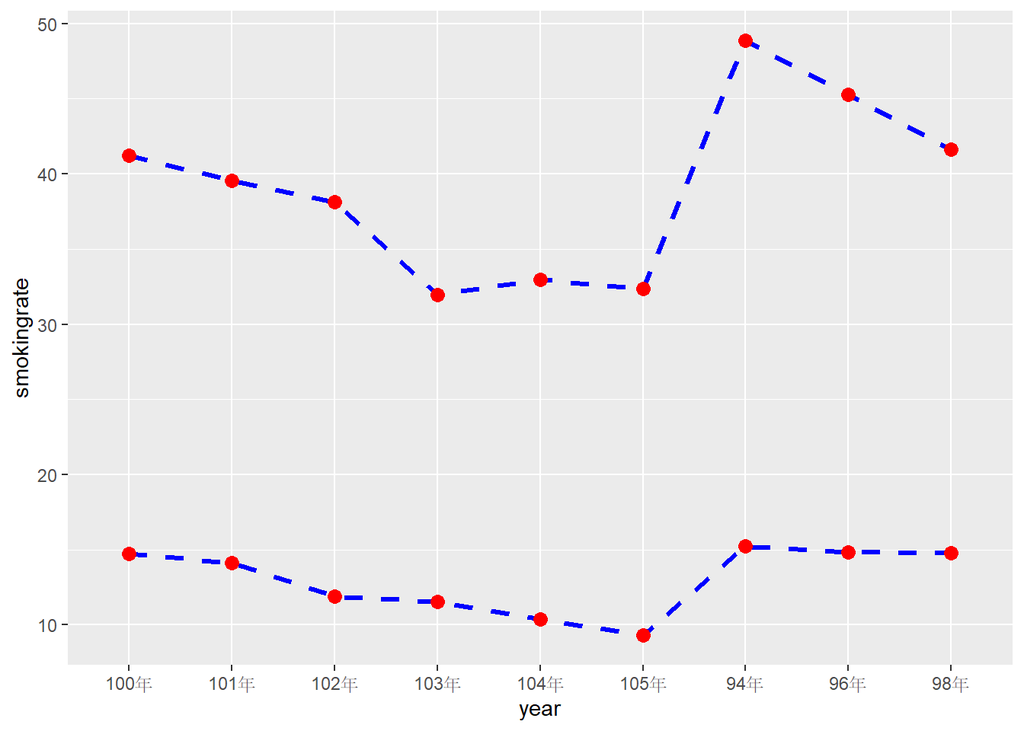